# Visualization Lab 2

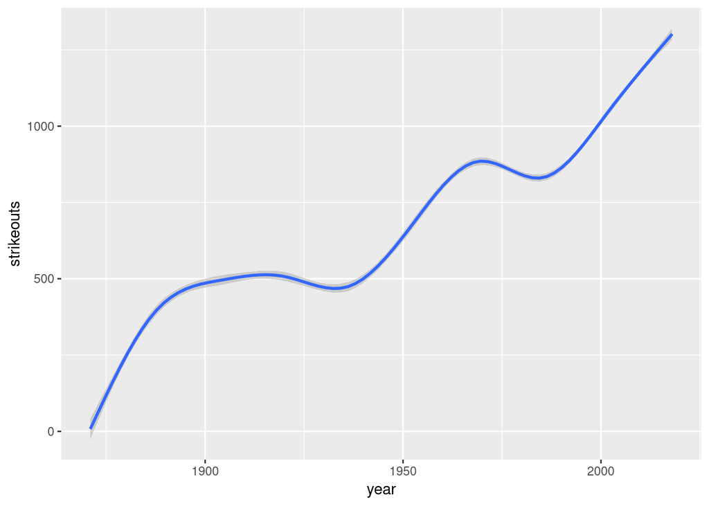

```r
## A smooth line
ggplot(data = mlb, aes(x = year, y = strikeouts)) + geom_smooth()
```

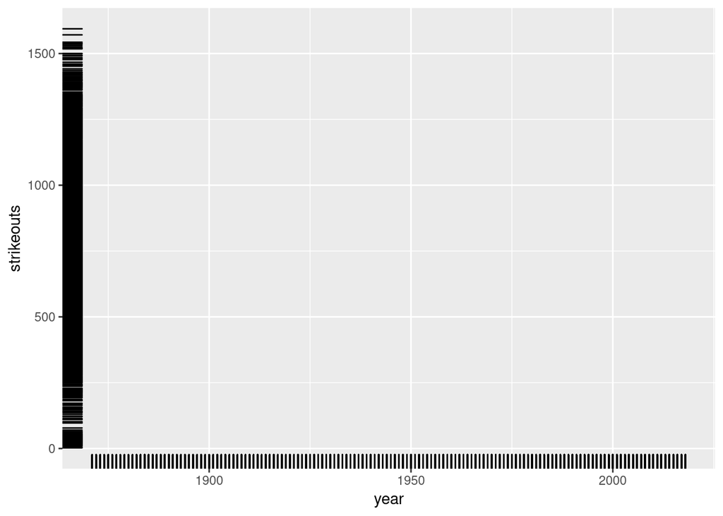

```r
## A rug plot (shows density of observations)
ggplot(data = mlb, aes(x = year, y = strikeouts)) + geom_rug()
```

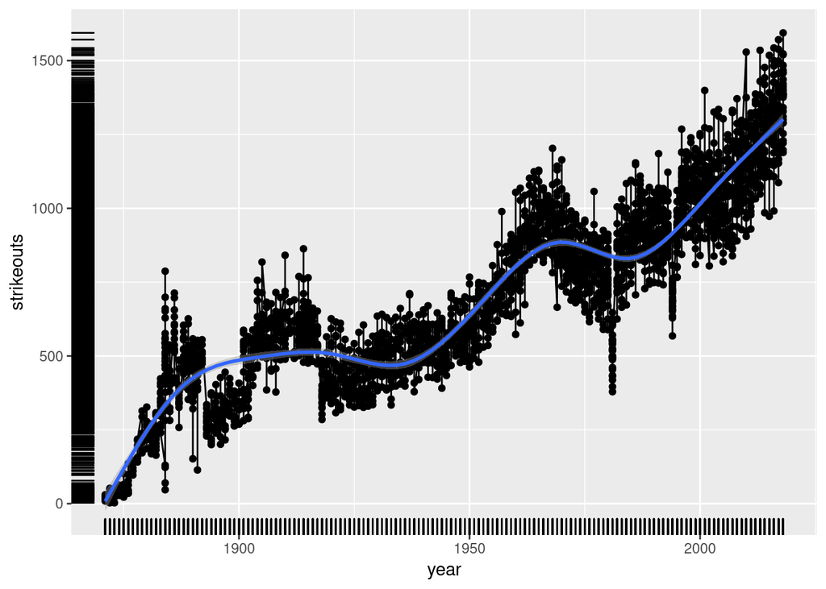

```r
## All together
ggplot(data = mlb, aes(x = year, y = strikeouts)) + geom_point() + geom_line() + geom_smooth() + geom_rug()
```

A subtle point here is that each addition is a layer that is put *on top* of the previous layer. This note can really help you put the finishing touches on graphs.

**Question 4**. Try out at least two of the `geom_*` functions on the data for hits vs. sacrifice flies. Try exploring with some more `geom_*` functions [here](https://www.rstudio.com/wp-content/uploads/2015/03/ggplot2-cheatsheet.pdf). Are there any that cause an error?

```r
## R code here
```

## Presentation

The package `ggplot2` does a lot of the heavy lifting when it comes to make interesting plots, given we have the data in the proper structure. However, it just as important that our plots are **readable**. Many people (maybe your future boss and definitely your current TAs) like to be able to view figures and graphs as objects that can stand on their own. This means that we should not have to look elsewhere in the text to understand the **main** ideas your plot is trying to convey. At a bare minimum this means any plot should have

1. A meaningful title
2. Meaningful axis titles and legend titles
3. One or two clear concepts (as opposed to trying to show everything about your data in one plot **or** being very repetitive in the features shown)
4. Consideration for `data ink` (the concept that if something does not meaningfully contribute to a figure, is it really necessary?)

**Question 5**. Consider the plot shown below. What can you say about this plot with regards to the 4 criteria listed above?

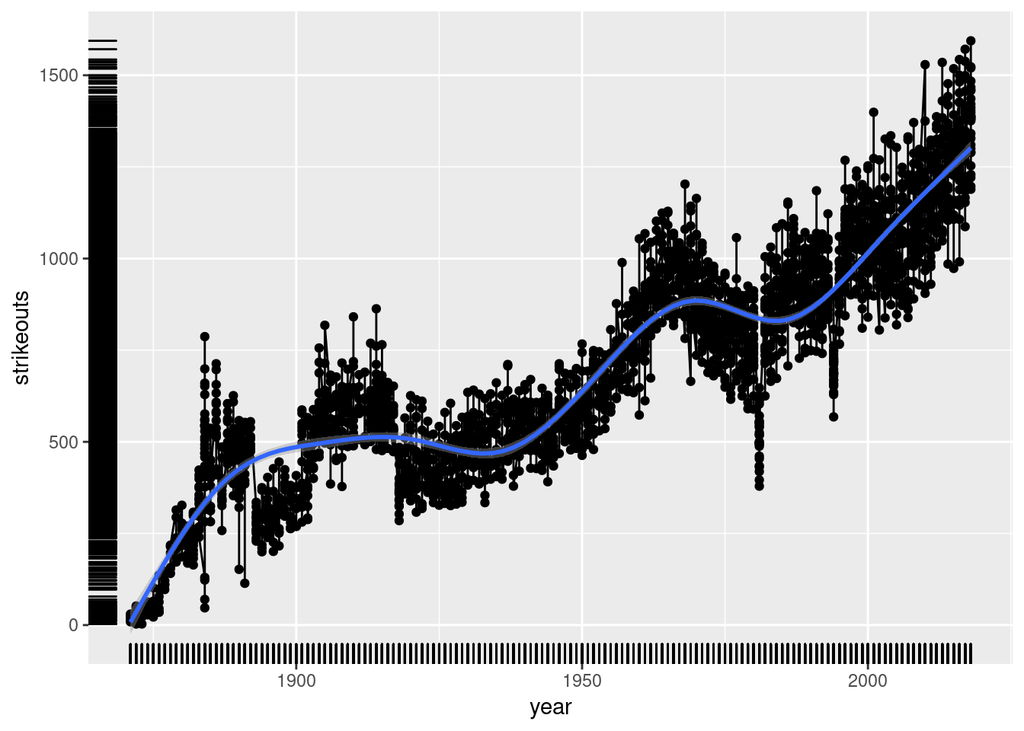

```
## Answer here
```

```r
## All together
ggplot(data = mlb, aes(x = year, y = strikeouts)) + geom_point() + geom_line() + geom_smooth() + geom_rug()
```

Again, fortunately for us, `ggplot` gives us some functions to help with the above. We also have to use our good judgment. “Make good decisions” - Anonymous.

Specifically, we will make use of the `labs()` function and the `theme_*()` functions. The second will especially become more important as we progress this summer.

We will also show how we can build the plot dynamically.

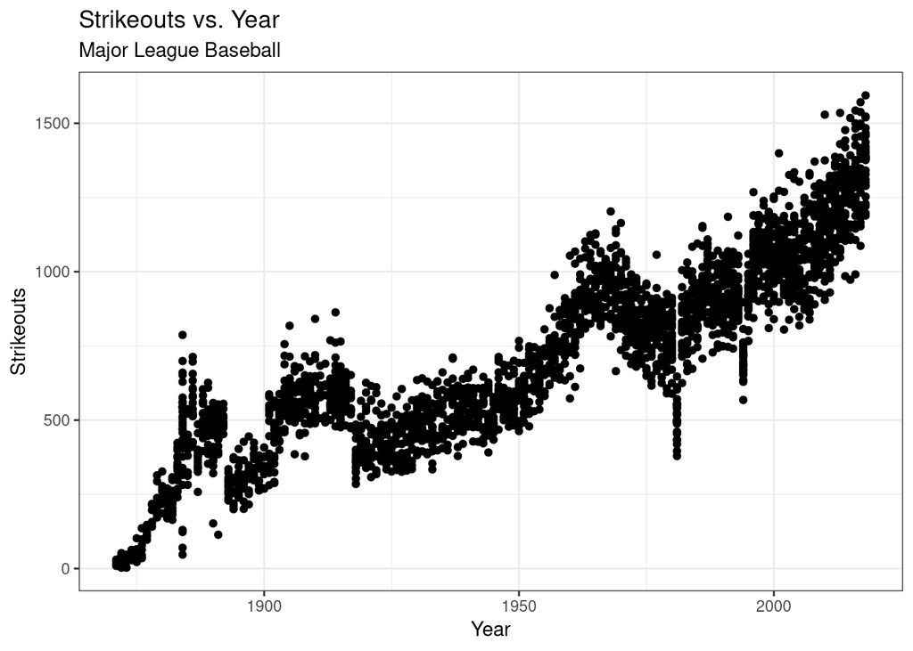

```r
g <- ggplot(data = mlb, aes(x = year, y = strikeouts)) + geom_point()
g + labs(x = "Year", y = "Strikeouts",
         title = "Strikeouts vs. Year",
         subtitle = "Major League Baseball") +
  theme_bw()
```

**Question 6**. Create a scatterplot of hits vs. sacrifice flies with better respect to the 4 criteria listed above. Also add a smooth trend line to the plot.

```r
## R code here
#
```

## Life in color

`ggplot2` does about 80% of the heavy lifting for you when it comes to making informative and professional visualizations. The other 20% can be a total pain and the bane of your existence. We will try to minimize this struggle.

We will first look at the struggle through the lens of colors.

**Question 7**.

The first point we will cover is attributes within `aes()` and those outside `aes`. Compare these two graphs where we change the color of the points.

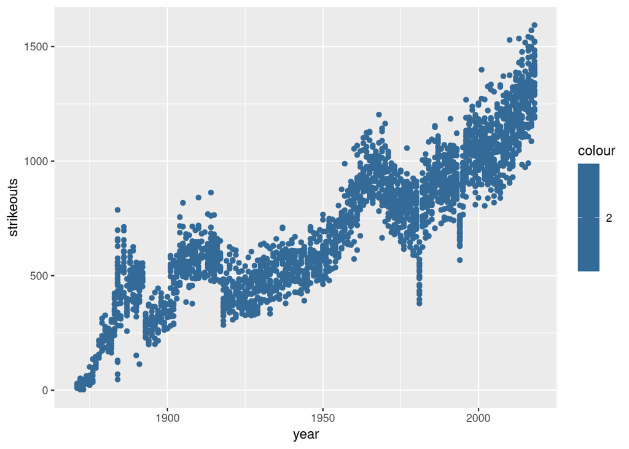

```r
ggplot(data = mlb, aes(x = year, y = strikeouts, col = 2)) + geom_point()
```

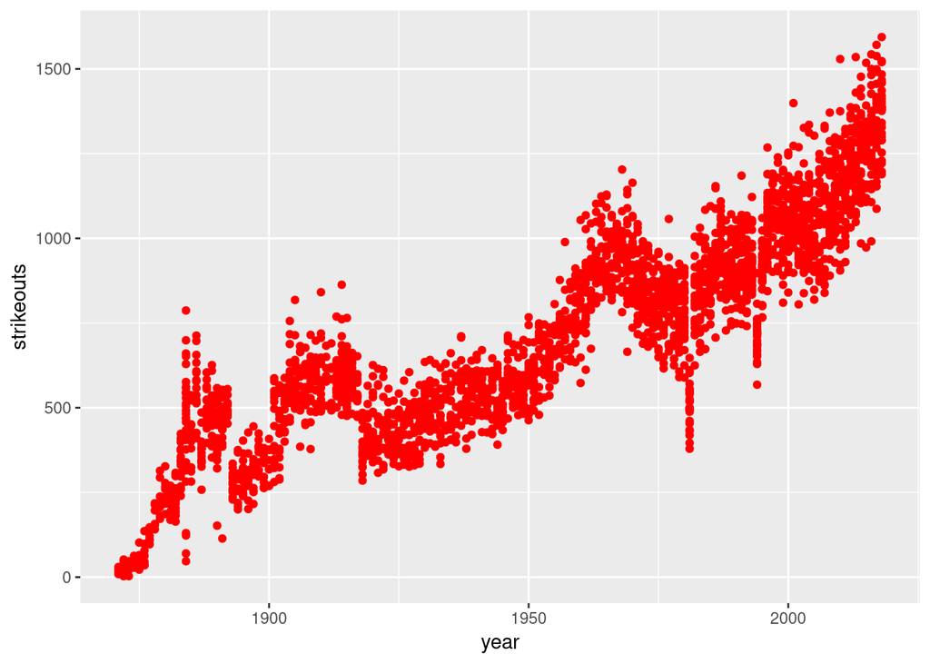

```r
ggplot(data = mlb, aes(x = year, y = strikeouts)) + geom_point(col = 2)
```

In the first plot, `col` is in `aes()`. It first looks for the `2` column from your data, `mlb`. It fails to find such a column. It then decides to map the the numeric `2` to every row in the data as the color. Since `2` is numeric (as opposed to a factor), ``ggplot2` gives you an entire color bar that only has one color. Try putting `factor(2)` instead of `2` in the first plot.

In the second plot, `col` is outside `aes()` and 2 is the numeric equivalent for red in `R`. Try putting another number in. Try putting `"red"` in. Then try `"cornflowerblue"`. Find your favorite color and try it out [here](http://www.stat.columbia.edu/~tzheng/files/Rcolor.pdf). Notice that the arguments outside of `aes()` don’t put a legend in your plot.

**Question 8**. Let us color the points by whether the team won the World Series or not.

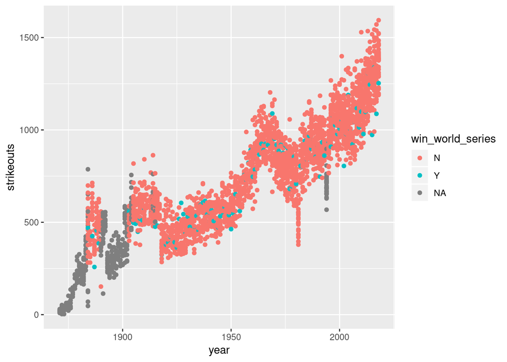

```r
ggplot(data = mlb, aes(x = year, y = strikeouts, col = win_world_series)) + geom_point()
```

```r
mlb$strikeouts2 <- mlb$strikeouts ## Make a copy of strikeouts
mlb$strikeouts2 <- ifelse(as.character(mlb$win_world_series) == "Y", mlb$strikeouts2, NA) # Only keep winners
```

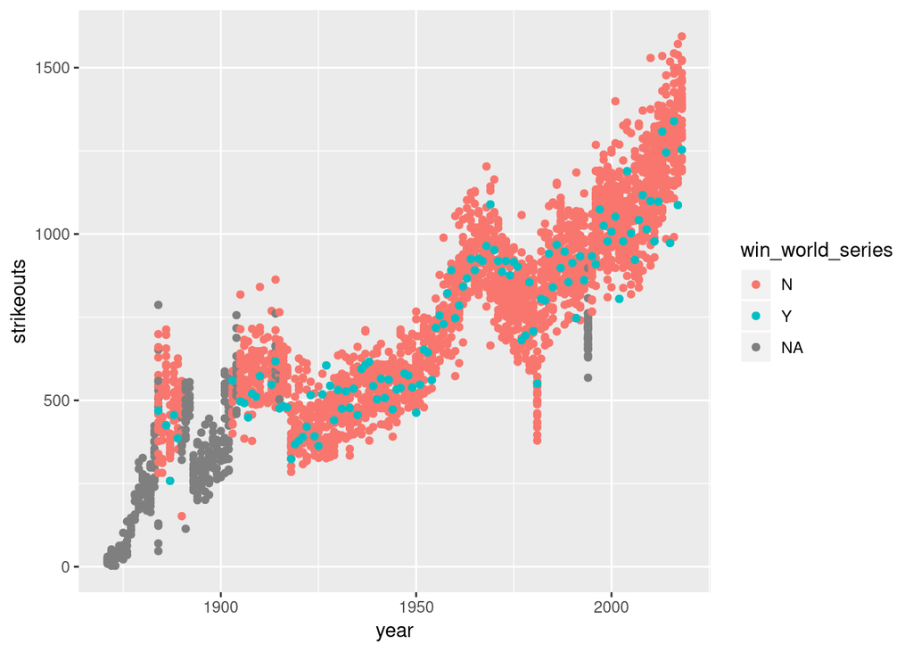

```r
ggplot(data = mlb, aes(x = year, col = win_world_series)) + geom_point(aes(y = strikeouts))  +
  geom_point(aes(y = strikeouts2))
```

The points are now on top. It looks better, don’t you think? Don’t be afraid to manipulate your data, but try to always make new copies. Can you put the all the “Y”s on top?

```r
## R code here
```

**Question 9**.

The next step is the legend. We will put a better title on it while changing the colors and changing the label names. We will also put our title and axes titles in and change the theme.

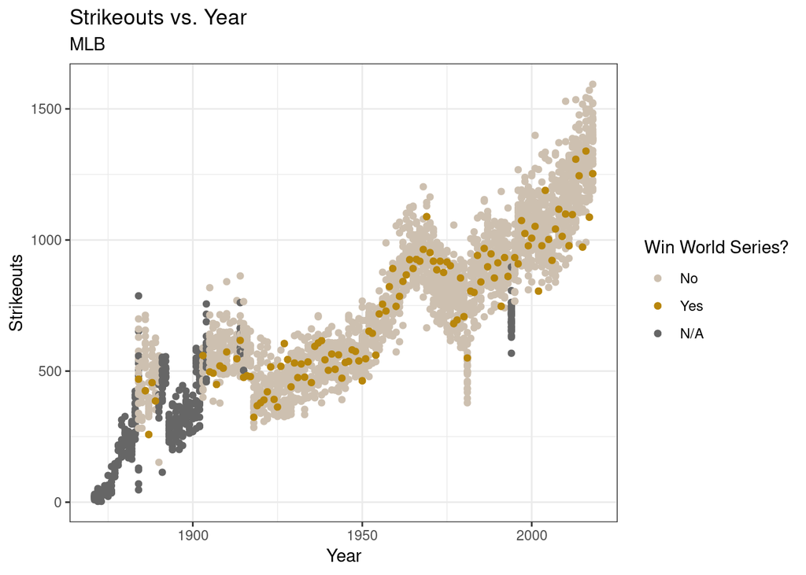

```r
g <- ggplot(data = mlb, aes(x = year, col = win_world_series)) + geom_point(aes(y = strikeouts))  +
  geom_point(aes(y = strikeouts2)) +
  scale_color_manual(name = "Win World Series?",
                     values = c("antiquewhite3", "darkgoldenrod"),
                     na.value = "gray40",
                     labels = c("No", "Yes", "N/A")) +
  labs(x = "Year", y = "Strikeouts",
       title = "Strikeouts vs. Year",
       subtitle = "MLB") + theme_bw()
g
```

This is pretty good and about 95% of the way there. Unfortunately, if you are putting this figure in a presentation or a paper, the default text size is way too small. It always best to assume that people can’t see well and work from there.

So we get to mess with the [theme](https://ggplot2.tidyverse.org/reference/ggtheme.html).

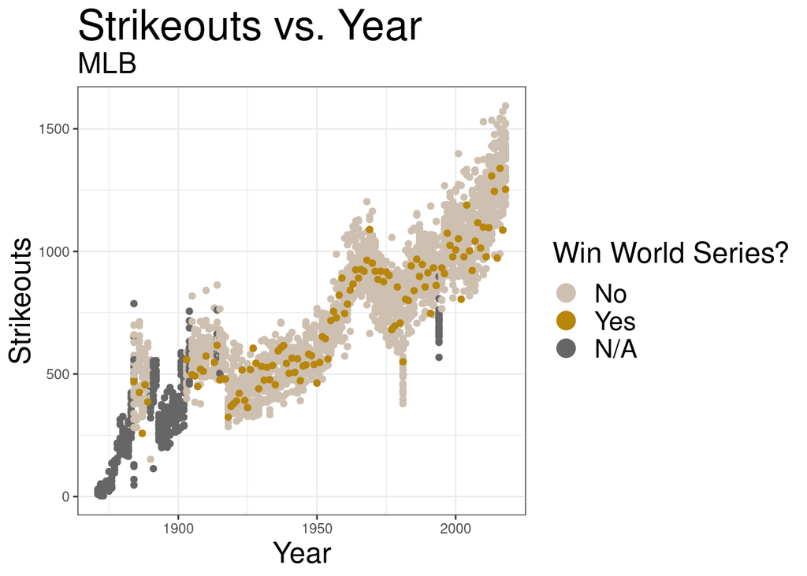

```r
g <- ggplot(data = mlb, aes(x = year, col = win_world_series)) + geom_point(aes(y = strikeouts))  +
  geom_point(aes(y = strikeouts2)) +
  scale_color_manual(name = "Win World Series?",
                     values = c("antiquewhite3", "darkgoldenrod"),
                     na.value = "gray40",
                     labels = c("No", "Yes", "N/A")) +
  labs(x = "Year", y = "Strikeouts",
       title = "Strikeouts vs. Year",
       subtitle = "MLB") +
  theme_bw() +
  theme(legend.title = element_text(size = 18),
        plot.title = element_text(size = 26),
        plot.subtitle = element_text(size = 18),
        axis.title = element_text(size = 18),
        legend.text = element_text(size = 16)) +
  guides(color = guide_legend(override.aes = list(size = 5)))  ## This gives us the big point in the legend
g
```

Can you repeat the above exercise with another variable?

**Question 9**.

Finally, we would like to save the plot. One way is to right click and select “Save Image.” The function `ggsave()` gives us a lot of control over how to save images. If you happen to be making a bunch of plots, over a loop for instance, it will be useful to learn how `ggsave()` works.

The function `ggsave()` will save the last plot (it must be a `ggobject`) you displayed, in this case what we stored in the object `g`.

```r
g
ggsave("strikeouts-vs-year.png", width = 8, height = 6)
```

What happens if you replace with `.pdf` with `.png`. Open up both the pdf and the png. Zoom in on the pdf. Zoom in on the png. Is there a difference?

## Bonus exercises

Where the bonus is you spending even more time looking at a screen.

1. Draw a sketch of your visualization for Question 1. Can you outline a 5 minute presentation? What are the main points you would make?
2. Instead of coloring the strikeouts vs. year by whether the team won the world series, color them by team ID. (This will probably be a mess since there are so many teams).
3. Pick 8 teams and subset the MLB data to those teams.
1. Plot Homeruns vs. Hits.
2. Color the points by the team.
3. Change the colors of the teams to actually match the teams’ colors.
4. What can you conclude from your plot? Point out at least three features.